# 탐색적자료분석 3장 후반 과제

215083 박재석

2024-04-15

준비사항

```r
library(tidyverse)
library(nycflights13)
```

### 3.6.2 count()를 사용하지 않고 같은 결과 내기

```r
not_cancelled %>%
    group_by(dest) %>%
    summarise(n_dest= n())
```

```
## # A tibble: 104 × 2
##    dest  n_dest
##    <chr>  <int>
##  1 ABQ      254
##  2 ACK      264
##  3 ALB      418
##  4 ANC        8
##  5 ATL    16837
##  6 AUS     2411
##  7 AVL      261
##  8 BDL      412
##  9 BGR      358
## 10 BHM      269
## # ℹ 94 more rows
```

group_by()와 summarise(), n()을 사용해 count()와 동일한 결과를 낼 수 있다.

```r
not_cancelled %>%
    group_by(tailnum) %>%
    summarise(sum_dis = sum(distance))
```

```
## # A tibble: 4,037 × 2
##    tailnum sum_dis
##    <chr>     <dbl>
##  1 D942DN     3418
##  2 N0EGMQ   239143
##  3 N10156   109664
##  4 N102UW    25722
##  5 N103US    24619
##  6 N104UW    24616
##  7 N10575   139903
##  8 N105UW    23618
##  9 N107US    21677
## 10 N108UW    32070
## # ℹ 4,027 more rows
```

group_by(), summarise(), sum()을 이용해 count()에서의의 가중치 변수 사용과 동일한 결과를 낼 수 있다.

### 3.6.4 일간 취소된 항공편의 수와 비율을 살펴보고, 평균지연시간과의 관련성알아보기

```r
flights %>%
    filter(is.na(dep_time),is.na(arr_time)) %>%
    summarise(cancelled = n())
```

```
## # A tibble: 1 × 1
##   cancelled
##       <int>
## 1      8255
```

취소된 항공편의 수를 알아보기 위해 is.na()를 이용해 출발 및 도착 시간이 없는 항공을 추출한 후 n()함수를 이용해 그 개수를 셌다. 그 결과 충 8255편의 항공편이 취소되었음을 알 수 있다.

```r
flights %>%
    filter(is.na(dep_time),is.na(arr_time)) %>%
    group_by(year, month, day) %>%
    summarise(cancelled = n()) %>%
    arrange(desc(cancelled))
```

```
## # A tibble: 358 × 4
## # Groups:   year, month [12]
##     year month   day cancelled
##    <int> <int> <int>     <int>
##  1  2013     2     8       472
##  2  2013     2     9       393
##  3  2013     5    23       221
##  4  2013    12    10       204
##  5  2013     9    12       192
##  6  2013     3     6       180
##  7  2013     3     8       180
##  8  2013    12     5       158
##  9  2013    12    14       125
## 10  2013     6    28       123
## # ℹ 348 more rows
```

```r
flights %>%
    group_by(year, month, day) %>%
    summarise(cancelled = mean(is.na(dep_time)&is.na(arr_time))) %>%
    arrange(desc(cancelled))
```

```
## # A tibble: 365 × 4
## # Groups:   year, month [12]
##     year month   day cancelled
##    <int> <int> <int>     <dbl>
##  1  2013     2     9     0.575
##  2  2013     2     8     0.508
##  3  2013     5    23     0.224
##  4  2013    12    10     0.216
##  5  2013     9    12     0.194
##  6  2013     3     6     0.185
##  7  2013     3     8     0.184
##  8  2013    12    14     0.181
##  9  2013    12     5     0.163
## 10  2013     6    28     0.124
## # ℹ 355 more rows
```

일별 취소항공편의 비율을 mean(조건)을 이용해 살펴 볼 수 있다. 2월 9일이 약57%로 취소된 비율이 가장 높은 것을 알 수 있다.

```r
flights %>%
    group_by(year, month, day) %>%
    summarise(ave_dep_delay = mean(dep_delay,na.rm = T)) %>%
    arrange(desc(ave_dep_delay))
```

```
## # A tibble: 365 × 4
## # Groups:   year, month [12]
##     year month   day ave_dep_delay
##    <int> <int> <int>         <dbl>
##  1  2013     3     8          83.5
##  2  2013     7     1          56.2
##  3  2013     9     2          53.0
##  4  2013     7    10          52.9
##  5  2013    12     5          52.3
##  6  2013     5    23          51.1
##  7  2013     9    12          50.0
##  8  2013     6    28          48.8
##  9  2013     6    24          47.2
## 10  2013     7    22          46.7
## # ℹ 355 more rows
```

평균출발지연시간은 3월 8일이 약 83분으로 가장 길다.

```r
flights %>%
    group_by(year, month, day) %>%
    summarise(ave_arr_delay = mean(arr_delay,na.rm = T)) %>%
    arrange(desc(ave_arr_delay))
```

```
## # A tibble: 365 × 4
## # Groups:   year, month [12]
##     year month   day ave_arr_delay
##    <int> <int> <int>         <dbl>
##  1  2013     3     8          85.9
##  2  2013     6    13          63.8
##  3  2013     7    22          62.8
##  4  2013     5    23          62.0
##  5  2013     7    10          59.6
##  6  2013     9    12          58.9
##  7  2013     7     1          58.3
##  8  2013    12    17          55.9
##  9  2013     8     8          55.5
## 10  2013    12     5          51.7
## # ℹ 355 more rows
```

평균도착지연시간또한 3월 8일이 약 85분으로 가장 길다.

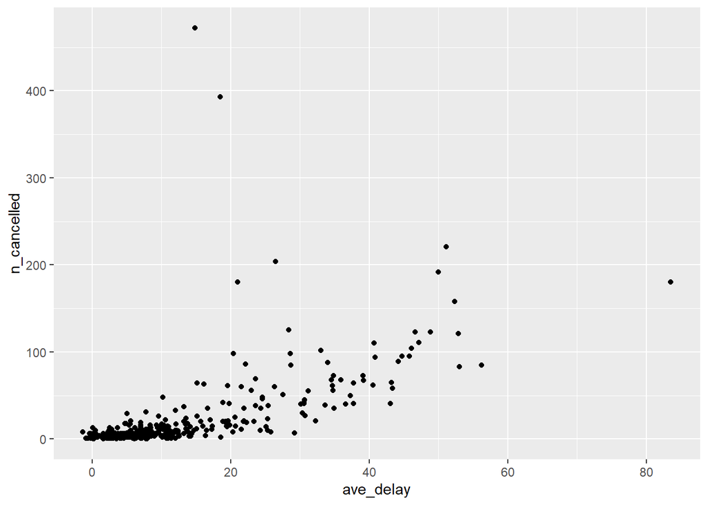

```
취소된 항공편 수와 평균지연시간 사이 관련성을 보기 위헤 일별 취소 항공편 수를 세 n_cancelled로, 일별 평균 지연시간을 계산 해 ave_delay로 새 변수를 지정했다. 이후 ggplot을 이용해 산점도를 그렸다. 산점도를 보면 지연시간이 길어질수록 취소를 많이 하는 경향이 있다. 그러나 앞서 본 듯 가장 많이 취소한 2월8일의 평균 지연시간은 높지 않음을 알 수 있다. 이를 통해 항공편의 취소를 설명할 수 있는 지연 시간보다 더 강력한 변수가 있음을 짐작할 수 있다.
```

```r
flights %>%
    group_by(year, month, day) %>%
    summarise(n_cancelled = sum(is.na(dep_time)), ave_delay = mean(dep_delay, na.rm = T)) %>%
    ggplot(aes(x= ave_delay, y=n_cancelled))+
    geom_point()
```

### 3.6.6 count()의 sort 인수의 역할

```r
?count
```

[결과]

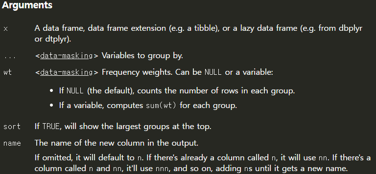

sort 인수를 사용하면 내림차순정렬을 할 수 있다.

```r
starwars %>%
    count(species)
```

```
## # A tibble: 38 × 2
##    species       n
##    <chr>     <int>
##  1 Aleena        1
##  2 Besalisk      1
##  3 Cerean        1
##  4 Chagrian      1
##  5 Clawdite      1
##  6 Droid         6
##  7 Dug           1
##  8 Ewok          1
##  9 Geonosian     1
## 10 Gungan        3
## # ℹ 28 more rows
```

count만 사용히면 기본적으로 선택한 변수기준 오름차순이다.

```r
starwars %>%
    count(species, sort = T)
```

```
## # A tibble: 38 × 2
##    species      n
##    <chr>    <int>
##  1 Human       35
##  2 Droid        6
##  3 <NA>         4
##  4 Gungan       3
##  5 Kaminoan     2
##  6 Mirialan     2
##  7 Twi'lek      2
##  8 Wookiee      2
##  9 Zabrak       2
## 10 Aleena       1
## # ℹ 28 more rows
```

sort 인수를 추가하여 그룹의 개수를 기준으로 내림차순 정렬할 수 있다.

- count()와 sort 인수의 사용

```r
flights %>%
    count(origin, sort = T)
```

```
## # A tibble: 3 × 2
##   origin      n
##   <chr>   <int>
## 1 EWR    120835
## 2 JFK    111279
## 3 LGA    104662
```

만약 가장 많은 항공이 출발하는 곳을 알고 싶다면 위와같이 사용해 뉴어크리버티국제공항(EWR)에서의 출발이 가장 많고 존 F.케네디국제공항(JFK), 라과디아공항(LGA)순으로 많이 출발하는 것을 알 수 있다.

```r
flights %>%
    count(month, sort = T)
```

```
## # A tibble: 12 × 2
##    month     n
##    <int> <int>
##  1     7 29425
##  2     8 29327
##  3    10 28889
##  4     3 28834
##  5     5 28796
##  6     4 28330
##  7     6 28243
##  8    12 28135
##  9     9 27574
## 10    11 27268
## 11     1 27004
## 12     2 24951
```

또는 위처럼 가장 많은 항공편이 운행된 달을 알고자할 때 count와 sort인수를 사용면 결과로부터 7월이 가장 많은 항공이 운행된 달 임을 쉽게 알 수 있다.

### 3.7.2 최악의 정시 기록을 가진 항공기 찾기

```r
flights %>%
    group_by(month, day, tailnum, arr_delay, dep_delay) %>%
    summarise() %>%
    arrange(desc(arr_delay))
```

```
## # A tibble: 333,936 × 5
## # Groups:   month, day, tailnum, arr_delay [332,316]
##    month   day tailnum arr_delay dep_delay
##    <int> <int> <chr>       <dbl>     <dbl>
##  1     1     9 N384HA       1272      1301
##  2     6    15 N504MQ       1127      1137
##  3     1    10 N517MQ       1109      1126
##  4     9    20 N338AA       1007      1014
##  5     7    22 N665MQ        989      1005
##  6     4    10 N959DL        931       960
##  7     3    17 N927DA        915       911
##  8     7    22 N6716C        895       898
##  9    12     5 N5DMAA        878       896
## 10     5     3 N523MQ        875       878
## # ℹ 333,926 more rows
```

arrange()를 사용해 도착지연시간을 내림차순정렬해 찾을 수 있다. 이로부터 찾아낸 가장 최악의 정시 기록을 가지고 있는 항공기는 N384HA이다. 1272분(약 21시간) 지연됐다.

```r
flights %>%
    group_by(year) %>%
    filter(rank(desc(arr_delay))==1) %>%
    summarise(tailnum, arr_delay)
```

```
## # A tibble: 1 × 3
##    year tailnum arr_delay
##   <int> <chr>       <dbl>
## 1  2013 N384HA       1272
```

#### 목적지별 총 지연 시간

```r
flights %>%
    group_by(dest) %>%
    mutate(sum_delay = sum(arr_delay, na.rm = T)) %>%
    select(dest,sum_delay)
```

```
## # A tibble: 336,776 × 2
## # Groups:   dest [105]
##    dest  sum_delay
##    <chr>     <dbl>
##  1 IAH       30046
##  2 IAH       30046
##  3 MIA        3467
##  4 BQN        7322
##  5 ATL      190260
##  6 ORD       97352
##  7 FLL       96153
##  8 IAD       74631
##  9 MCO       76185
## 10 ORD       97352
## # ℹ 336,766 more rows
```

group_by와 mutate를 이용해 도착지별 총 지연 시간을 계산 할 수 있다.

```r
flights %>%
    group_by(dest) %>%
    summarise(sum_delay = sum(arr_delay,na.rm = T))
```

```
## # A tibble: 105 × 2
##    dest  sum_delay
##    <chr>     <dbl>
##  1 ABQ        1113
##  2 ACK        1281
##  3 ALB        6018
##  4 ANC         -20
##  5 ATL      190260
##  6 AUS       14514
##  7 AVL        2089
##  8 BDL        2904
##  9 BGR        2874
## 10 BHM        4540
## # ℹ 95 more rows
```

summarise를 이용해서도 도착지별 지연시간 총 합을 똑같이 구할 수 있다. 이때는 중복된 그룹들을 하나로 볼 수 있다.

#### 항공편 별 목적지까지의 총 지연시간의 비율

```r
flights %>%
    group_by(dest) %>%
    filter(arr_delay>0) %>%
    mutate(per_delay = arr_delay/sum(arr_delay, na.rm = T)) %>%
    select(year:day, dest, per_delay)
```

```
## # A tibble: 133,004 × 5
## # Groups:   dest [103]
##     year month   day dest  per_delay
##    <int> <int> <int> <chr>     <dbl>
##  1  2013     1     1 IAH   0.000111
##  2  2013     1     1 IAH   0.000201
##  3  2013     1     1 MIA   0.000235
##  4  2013     1     1 ORD   0.0000424
##  5  2013     1     1 FLL   0.0000938
##  6  2013     1     1 ORD   0.0000283
##  7  2013     1     1 LAX   0.0000344
##  8  2013     1     1 DFW   0.000282
##  9  2013     1     1 ATL   0.0000400
## 10  2013     1     1 DTW   0.000116
## # ℹ 132,994 more rows
```

### 3.7.6 목적지별 의심스럽게 빠른 항공,상대 비행 시간 계산

#### 입력오류 의심되는 항공편 찾기

```r
flights %>%
    group_by(dest) %>%
    mutate(speed=distance/air_time,speed_999 = quantile(speed,0.999,na.rm=T), ave_speed = mean(speed, na.rm = T)) %>%
    select(year:day,dest,tailnum,speed, speed_999, ave_speed) %>%
    filter(speed>speed_999) %>%
    summarise(dest, tailnum, speed, ave_speed, speed_999) %>%
    arrange(desc(speed))
```

```
## # A tibble: 314 × 5
## # Groups:   dest [91]
##    dest  tailnum speed ave_speed speed_999
##    <chr> <chr>   <dbl>     <dbl>     <dbl>
##  1 ATL   N666DN  11.7       6.75      8.21
##  2 MSP   N17196  10.8       6.80      8.10
##  3 GSP   N14568  10.8       6.43      8.37
##  4 BNA   N12567  10.7       6.69      8.30
##  5 PBI   N956DL   9.86      7.13      8.55
##  6 SJU   N3768    9.4       8.09      9.24
##  7 SJU   N779JB   9.29      8.09      9.24
##  8 STT   N5FFAA   9.27      7.99      9.23
##  9 CVG   N11544   9.18      6.04      7.46
## 10 BQN   N37281   9.16      8.12      9.12
## # ℹ 304 more rows
```

mutate를 이용해 각 항공편 별로 distance/air_time을 계산해 speed변수를 만들고 각 목적지 별로 평균 속도, 속도가 quantile(speed, 0.999)를 이용해 상위 0.1%에 속하는 항공편을 찾았다. 상위 0.1%인 값보다 큰 속도를 가진 항공편들 중 평균속도와 많은 차이가 나면 입력오류를 의심해 볼 만하다.

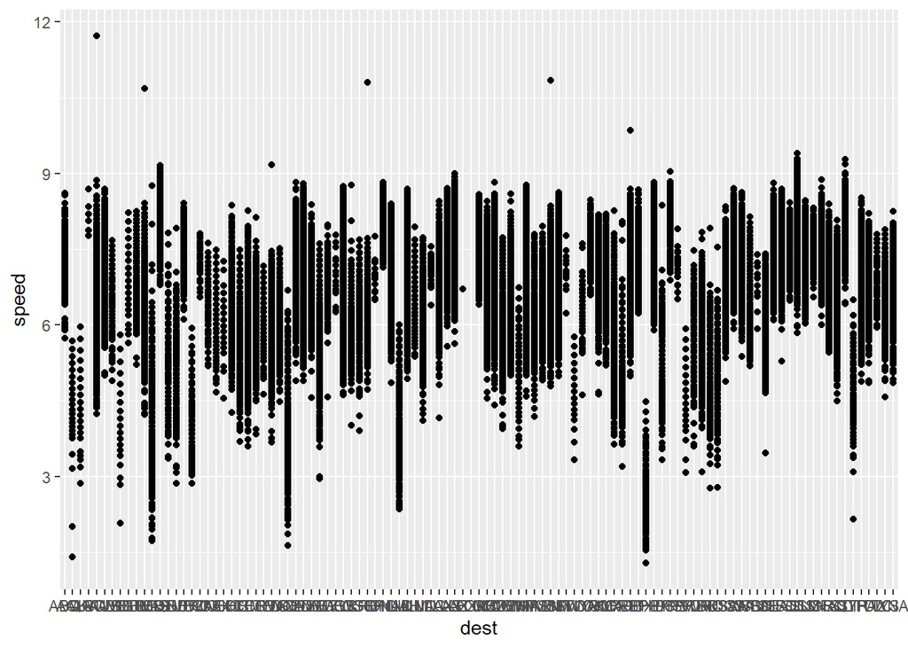

```r
flights %>%
    group_by(dest) %>%
    mutate(speed=distance/air_time) %>%
    summarise(speed) %>%
    ggplot(aes(x=dest, y=speed))+
    geom_point()
```

이상치 유무를 확인확인하기 위해 위와같이 시각화를 통해서도 볼 수 있다.

#### 동일 목적지까지 가장 짧은 비행을 기준으로 상대비행시간 계산

```r
flights %>%
    group_by(origin, dest) %>%
    mutate(min_airtime = min(air_time, na.rm = T),
           rel_airtime = air_time/min_airtime)
```

```
## # A tibble: 336,776 × 21
## # Groups:   origin, dest [224]
##     year month   day dep_time sched_dep_time dep_delay arr_time sched_arr_time
##    <int> <int> <int>    <int>          <int>     <dbl>    <int>          <int>
##  1  2013     1     1      517            515         2      830            819
##  2  2013     1     1      533            529         4      850            830
##  3  2013     1     1      542            540         2      923            850
##  4  2013     1     1      544            545        -1     1004           1022
##  5  2013     1     1      554            600        -6      812            837
##  6  2013     1     1      554            558        -4      740            728
##  7  2013     1     1      555            600        -5      913            854
##  8  2013     1     1      557            600        -3      709            723
##  9  2013     1     1      557            600        -3      838            846
## 10  2013     1     1      558            600        -2      753            745
## # ℹ 336,766 more rows
## # ℹ 13 more variables: arr_delay <dbl>, carrier <chr>, flight <int>,
## #   tailnum <chr>, origin <chr>, dest <chr>, air_time <dbl>, distance <dbl>,
## #   hour <dbl>, minute <dbl>, time_hour <dttm>, min_airtime <dbl>,
## #   rel_airtime <dbl>
```

```
먼저 group_by를 이용해 출발지와 목적지로 그룹화를 하였다. 같은 출발지에서 같은 목적지로 간 경우별로 보기 위함이다. min()을 이용해 목적지별 최단시간 비행 시간을 min_airtime으로 저장하고, 가장 짧은 비행 시간을 1로 하도록 비행 시간을 최소 비행시간으로 나눠 상대 비행시간 rel_airtime을 구했다.
```

#### 어떤 항공편이 비행 중 가장 지연되었는가

```r
#가장 상대 비행시간이 긴 항공편 찾기기
flights %>%
    group_by(origin, dest) %>%
    mutate(min_airtime = min(air_time, na.rm = T),
           rel_airtime = air_time/min_airtime) %>%
    select(year:day,tailnum,origin,dest, arr_delay, rel_airtime,) %>%
    arrange(desc(rel_airtime))
```

```
## # A tibble: 336,776 × 8
## # Groups:   origin, dest [224]
##     year month   day tailnum origin dest  arr_delay rel_airtime
##    <int> <int> <int> <chr>   <chr>  <chr>     <dbl>       <dbl>
##  1  2013     6    17 N967UW  LGA    BOS          41        5.10
##  2  2013     6    10 N745VJ  LGA    DCA         152        4.09
##  3  2013     6    29 N328JB  JFK    ACK          86        4.03
##  4  2013     6    24 N37255  EWR    BOS         101        3.73
##  5  2013     7    23 N3FKAA  JFK    BOS          53        3.69
##  6  2013     3    12 N946UW  LGA    BOS         115        3.67
##  7  2013     1    21 N956UW  LGA    BOS          22        3.62
##  8  2013     6    10 N755US  LGA    DCA          98        3.59
##  9  2013     7    23 N346NB  JFK    BOS          71        3.5
## 10  2013     5    21 N955UW  LGA    BOS          78        3.33
## # ℹ 336,766 more rows
```

```r
flights %>%
    group_by(origin, dest) %>%
    mutate(min_airtime = min(air_time, na.rm = T),
           rel_airtime = air_time/min_airtime) %>%
    select(year:day,tailnum,origin,dest, arr_delay, rel_airtime,) %>%
    #동일 항로별 상대 비행시간이 제일 긴 항공만 뽑기
    filter(rank(desc(rel_airtime))==1) %>%
    #그중 도착 지연 시간이 가장 긴 항공 찾기
    arrange(desc(arr_delay))
```

```
## # A tibble: 201 × 8
## # Groups:   origin, dest [201]
##     year month   day tailnum origin dest  arr_delay rel_airtime
##    <int> <int> <int> <chr>   <chr>  <chr>     <dbl>       <dbl>
##  1  2013     9     1 N346JB  JFK    SYR         350        2.77
##  2  2013     8     8 N593UA  EWR    SFO         345        1.42
##  3  2013    11    22 N852UA  EWR    LAS         330        1.56
##  4  2013    11    17 N411WN  LGA    MDW         276        1.96
##  5  2013     1     2 N21130  EWR    OKC         252        1.77
##  6  2013     9     2 N708EV  LGA    CHS         242        1.58
##  7  2013    12    14 N928MQ  JFK    ORF         224        2.08
##  8  2013     7    10 N353JB  JFK    ROC         221        2.71
##  9  2013     4    19 N12195  EWR    GSO         212        1.77
## 10  2013     6     3 N22909  EWR    DCA         186        2.28
## # ℹ 191 more rows
```

[output not shown]

### 3.7.8 각 항공기에 대해 처음으로 1시간 이상 지연 이전의 비행 횟수를 카운트

```r
flights %>%
    arrange(tailnum, time_hour) %>%
    group_by(tailnum) %>%
    mutate(is_delayed = dep_delay >=60) %>%
    filter(cumsum(is_delayed)<1) %>%  #첫 지연 이전 모든 비행 선택
    summarise(n_flight = n())
```

```
## # A tibble: 3,747 × 2
##    tailnum n_flight
##    <chr>      <int>
##  1 N0EGMQ        38
##  2 N10156         9
##  3 N102UW        25
##  4 N103US        46
##  5 N104UW         3
##  6 N105UW        22
##  7 N107US        20
##  8 N108UW        36
##  9 N109UW        28
## 10 N110UW        15
## # ℹ 3,737 more rows
```

```
먼저  arrange()를 이용해 항공기별 시간순으로 정렬했다. 이후 지연 시간이 60분 이상만 True를 반환하도록 is_delayed 변수를 만들어 cumsum으로 누적합을 구하고 이 누적합이 1이 되지 안는 부분까지를 가지고 온 후 n()을 이용해 그 수를 세었다.
```